# **Comparing Stats for Soccer Players Among Top 5 Leagues**

Ivo Tomasovich and Josh Allison

## **Project Goals**

Our goal is to take midfielders and compare their stats among the Premier League, La Liga, Series A, Bundesliga, and Ligue Un to determine which league has the best players in those positions on average.

## **Project Dataset**

The dataset we are using is for the 2022-2023 season. The data can be found on [Kaggle](https://www.kaggle.com/datasets/vivovinco/20222023-football-team-stats). The data has over 100 different stats for every single player in the top 5 leagues, such as goals scored, passes attempted, or tackles completed. In this dataset, the stats typically fall into one of two categories: a percentage of a completed action vs total attempts, or the total number of a specific action taken. This dataset is great for our analysis because of the quantity of different stats; we're able to get a very good understand of the quality of a player.

While this data does not contain any information about player price, as that can often help determine the perceived value of a plater, we plan to scrape TransferMarket in the future the get the value of each player in the dataset from the 2022-2023 season so we can see which leagues potentially have the best valued midfielders per stats.

## **Collaboration Plan**

Our collaboration plan is to meet in person once a week to work on the final project. We've shared the collab file with each other so we can work on it together. Over the next 2 months, we will continue creating charts using this dataset and scraping data from TransferMarket for the final project and presentation.

## **ETL (Extraction, Transform, and Load)**

First, we will load our [.csv](https://www.kaggle.com/datasets/vivovinco/20222023-football-team-stats) file from Kaggle and are going to filter by all available midfielders. Then, we will filter again by the statistics we want to use. After, we will sort by each league, so we can then take the average of each state per league, where we can finally have an aggregate ranking of which leagues have to highest amount of best stats.

```python
import pandas as pd
import numpy as np
import matplotlib.pyplot as plt

df = pd.read_csv('/content/2022-2023 Football Player Stats.csv')
df.head()
```

|  | Rk | Player | Nation | Pos | Squad | Comp | Age | Born | MP | Starts | ... | Off | Crs | TklW | PKwon | PKcon | OG | Recov | AerWon | AerLost | AerWon% |
| --- | --- | --- | --- | --- | --- | --- | --- | --- | --- | --- | --- | --- | --- | --- | --- | --- | --- | --- | --- | --- | --- |
| 0 | 1 | Brenden Aaronson | USA | MFFW | Leeds United | Premier League | 22 | 2000 | 20 | 19 | ... | 0.17 | 2.54 | 0.51 | 0.0 | 0.0 | 0.00 | 4.86 | 0.34 | 1.19 | 22.2 |
| 1 | 2 | Yunis Abdelhamid | MAR | DF | Reims | Ligue 1 | 35 | 1987 | 22 | 22 | ... | 0.05 | 0.18 | 1.59 | 0.0 | 0.0 | 0.00 | 6.64 | 2.18 | 1.23 | 64.0 |
| 2 | 3 | Himad Abdelli | FRA | MFFW | Angers | Ligue 1 | 23 | 1999 | 14 | 8 | ... | 0.00 | 1.05 | 1.40 | 0.0 | 0.0 | 0.00 | 8.14 | 0.93 | 1.05 | 47.1 |
| 3 | 4 | Salis Abdul Samed | GHA | MF | Lens | Ligue 1 | 22 | 2000 | 20 | 20 | ... | 0.00 | 0.35 | 0.80 | 0.0 | 0.0 | 0.05 | 6.60 | 0.50 | 0.50 | 50.0 |
| 4 | 5 | Laurent Abergel | FRA | MF | Lorient | Ligue 1 | 30 | 1993 | 15 | 15 | ... | 0.00 | 0.23 | 2.02 | 0.0 | 0.0 | 0.00 | 6.51 | 0.31 | 0.39 | 44.4 |

5 rows × 124 columns

1. Filter by Position. We are choosing to look at all midfielders in this dataset
2. Filter by Stats
3. Filter by leagues
4. Average by leagues

# **Filter by position**

We filter out all the positions so the dataframe only shows us stats from the midfielders. Using the stats of one position will make it more feasible to compare quality of the players.

```python
midfielder_df = df[df['Pos'].isin(['MF'])]
midfielder_df
```

|  | Rk | Player | Nation | Pos | Squad | Comp | Age | Born | MP | Starts | ... | Off | Crs | TklW | PKwon | PKcon | OG | Recov | AerWon | AerLost | AerWon% |
| --- | --- | --- | --- | --- | --- | --- | --- | --- | --- | --- | --- | --- | --- | --- | --- | --- | --- | --- | --- | --- | --- |
| 3 | 4 | Salis Abdul Samed | GHA | MF | Lens | Ligue 1 | 22 | 2000 | 20 | 20 | ... | 0.00 | 0.35 | 0.80 | 0.0 | 0.0 | 0.05 | 6.60 | 0.50 | 0.50 | 50.0 |
| 4 | 5 | Laurent Abergel | FRA | MF | Lorient | Ligue 1 | 30 | 1993 | 15 | 15 | ... | 0.00 | 0.23 | 2.02 | 0.0 | 0.0 | 0.00 | 6.51 | 0.31 | 0.39 | 44.4 |
| 5 | 6 | Oliver Abildgaard | DEN | MF | Hellas Verona | Serie A | 26 | 1996 | 1 | 0 | ... | 0.00 | 0.00 | 10.00 | 0.0 | 0.0 | 0.00 | 10.00 | 0.00 | 10.00 | 0.0 |
| 15 | 16 | Tyler Adams | USA | MF | Leeds United | Premier League | 23 | 1999 | 19 | 19 | ... | 0.05 | 0.11 | 2.00 | 0.0 | 0.0 | 0.00 | 8.68 | 0.89 | 0.63 | 58.6 |
| 25 | 26 | Lucien Agoume | FRA | MF | Troyes | Ligue 1 | 21 | 2002 | 5 | 4 | ... | 0.31 | 0.94 | 2.19 | 0.0 | 0.0 | 0.00 | 5.63 | 3.13 | 0.63 | 83.3 |
| ... | ... | ... | ... | ... | ... | ... | ... | ... | ... | ... | ... | ... | ... | ... | ... | ... | ... | ... | ... | ... | ... |
| 2671 | 2672 | Piotr Zieli?ski | POL | MF | Napoli | Serie A | 28 | 1994 | 21 | 16 | ... | 0.14 | 3.90 | 0.41 | 0.0 | 0.0 | 0.00 | 4.04 | 0.14 | 0.55 | 20.0 |
| 2683 | 2684 | Martín Zubimendi | ESP | MF | Real Sociedad | La Liga | 24 | 1999 | 19 | 18 | ... | 0.06 | 0.11 | 1.07 | 0.0 | 0.0 | 0.00 | 6.18 | 2.19 | 0.90 | 70.9 |
| 2684 | 2685 | Szymon ?urkowski | POL | MF | Fiorentina | Serie A | 25 | 1997 | 2 | 0 | ... | 0.00 | 2.50 | 0.00 | 0.0 | 0.0 | 0.00 | 5.00 | 2.50 | 2.50 | 50.0 |
| 2685 | 2686 | Szymon ?urkowski | POL | MF | Spezia | Serie A | 25 | 1997 | 1 | 0 | ... | 0.00 | 0.00 | 0.00 | 0.0 | 0.0 | 0.00 | 30.00 | 0.00 | 0.00 | 0.0 |
| 2686 | 2687 | Martin Ødegaard | NOR | MF | Arsenal | Premier League | 24 | 1998 | 20 | 20 | ... | 0.05 | 2.51 | 0.70 | 0.0 | 0.0 | 0.00 | 5.19 | 0.48 | 0.70 | 40.9 |

608 rows × 124 columns

## Filter by stats

```python
midfielder_df = midfielder_df.loc[:, ['Rk', 'Player', 'Nation', 'Pos', 'Squad', 'Comp', 'MP',
                                      '90s', 'Goals', 'PasTotCmp', 'PasTotAtt', 'PasTotCmp%',
                                      'PasTotDist', 'PasTotPrgDist', 'PasShoCmp', 'PasShoAtt', 'PasShoCmp%',
                                      'PasMedCmp', 'PasMedAtt', 'PasMedCmp%', 'PasLonCmp', 'PasLonAtt', 'PasLonCmp%',
                                      'Assists', 'PasAss', 'Pas3rd', 'PPA', 'CrsPA', 'PasProg', 'PasAtt',
                                      'PasLive', 'PasDead', 'PasFK', 'TB', 'Sw', 'PasCrs', 'TI', 'CK',
                                      'CkIn', 'CkOut', 'CkStr', 'PasCmp', 'SCA']]

midfielder_df
```

|  | Rk | Player | Nation | Pos | Squad | Comp | MP | 90s | Goals | PasTotCmp | ... | TB | Sw | PasCrs | TI | CK | CkIn | CkOut | CkStr | PasCmp | SCA |
| --- | --- | --- | --- | --- | --- | --- | --- | --- | --- | --- | --- | --- | --- | --- | --- | --- | --- | --- | --- | --- | --- |
| 3 | 4 | Salis Abdul Samed | GHA | MF | Lens | Ligue 1 | 20 | 20.0 | 1 | 59.5 | ... | 0.05 | 0.20 | 0.35 | 0.10 | 0.00 | 0.00 | 0.00 | 0.00 | 59.5 | 1.60 |
| 4 | 5 | Laurent Abergel | FRA | MF | Lorient | Ligue 1 | 15 | 12.9 | 0 | 37.9 | ... | 0.39 | 0.16 | 0.23 | 0.00 | 0.00 | 0.00 | 0.00 | 0.00 | 37.9 | 1.24 |
| 5 | 6 | Oliver Abildgaard | DEN | MF | Hellas Verona | Serie A | 1 | 0.1 | 0 | 20.0 | ... | 0.00 | 0.00 | 0.00 | 0.00 | 0.00 | 0.00 | 0.00 | 0.00 | 20.0 | 0.00 |
| 15 | 16 | Tyler Adams | USA | MF | Leeds United | Premier League | 19 | 19.0 | 0 | 47.1 | ... | 0.05 | 0.05 | 0.11 | 0.68 | 0.00 | 0.00 | 0.00 | 0.00 | 47.1 | 1.84 |
| 25 | 26 | Lucien Agoume | FRA | MF | Troyes | Ligue 1 | 5 | 3.2 | 0 | 47.5 | ... | 0.00 | 0.94 | 0.94 | 0.31 | 0.31 | 0.31 | 0.00 | 0.00 | 47.5 | 1.56 |
| ... | ... | ... | ... | ... | ... | ... | ... | ... | ... | ... | ... | ... | ... | ... | ... | ... | ... | ... | ... | ... | ... |
| 2671 | 2672 | Piotr Zieli?ski | POL | MF | Napoli | Serie A | 21 | 14.6 | 3 | 47.2 | ... | 0.00 | 0.34 | 3.90 | 0.07 | 2.81 | 1.30 | 0.96 | 0.00 | 47.2 | 4.73 |
| 2683 | 2684 | Martín Zubimendi | ESP | MF | Real Sociedad | La Liga | 19 | 17.8 | 1 | 45.0 | ... | 0.17 | 0.28 | 0.11 | 0.11 | 0.00 | 0.00 | 0.00 | 0.00 | 45.0 | 1.29 |
| 2684 | 2685 | Szymon ?urkowski | POL | MF | Fiorentina | Serie A | 2 | 0.4 | 0 | 42.5 | ... | 0.00 | 0.00 | 2.50 | 0.00 | 0.00 | 0.00 | 0.00 | 0.00 | 42.5 | 5.00 |
| 2685 | 2686 | Szymon ?urkowski | POL | MF | Spezia | Serie A | 1 | 0.1 | 0 | 20.0 | ... | 0.00 | 0.00 | 0.00 | 0.00 | 0.00 | 0.00 | 0.00 | 0.00 | 20.0 | 0.00 |
| 2686 | 2687 | Martin Ødegaard | NOR | MF | Arsenal | Premier League | 20 | 18.7 | 8 | 38.3 | ... | 0.80 | 0.21 | 2.51 | 0.32 | 0.59 | 0.21 | 0.21 | 0.05 | 38.3 | 5.08 |

608 rows × 43 columns

# **Filter by League**

We group all of the stats together by taking the averages of all the players in that specific league. This gives us a better view of which league has players that do certain things better.

```python
averages_by_league = midfielder_df.groupby('Comp').mean(numeric_only=True)
print(averages_by_league)
```

```
                         Rk         MP       90s     Goals  PasTotCmp  \
Comp
Bundesliga      1417.369369  11.333333  7.770270  0.792793  30.093063
La Liga         1347.928000  11.448000  7.720800  0.624000  36.183200
Ligue 1         1360.051282  12.581197  8.772650  0.769231  44.825641
Premier League  1403.208696  11.721739  8.563478  0.817391  38.037391
Serie A         1331.350000  11.814286  7.749286  0.764286  37.874286

                PasTotAtt  PasTotCmp%  PasTotDist  PasTotPrgDist  PasShoCmp  \
Comp
Bundesliga      38.742342   74.001802  494.257658     147.118018  14.481351
La Liga         44.400800   79.772800  599.138400     170.980000  18.297120
Ligue 1         53.639316   82.896581  753.770940     209.871795  21.241624
Premier League  47.012174   80.081739  635.020000     176.913043  18.395652
Serie A         46.575000   78.210714  632.237857     173.335714  18.443000

                ...        TB        Sw    PasCrs        TI        CK  \
Comp            ...
Bundesliga      ...  0.230090  0.199820  1.223333  0.254685  0.496396
La Liga         ...  0.153360  0.595120  1.557440  0.250640  0.597360
Ligue 1         ...  0.231795  0.404701  1.576068  0.238291  0.668034
Premier League  ...  0.228870  0.377391  1.323130  0.302522  0.486000
Serie A         ...  0.106857  0.445143  1.766857  0.263929  0.665714

                    CkIn     CkOut     CkStr     PasCmp       SCA
Comp
Bundesliga      0.161441  0.251441  0.005135  30.093063  2.278378
La Liga         0.203200  0.263440  0.005760  36.183200  2.286240
Ligue 1         0.326496  0.217692  0.002393  44.825641  2.741282
Premier League  0.316696  0.099826  0.005652  38.037391  2.225391
Serie A         0.256286  0.312429  0.000786  37.874286  2.424286

[5 rows x 38 columns]
```

# **Ranked Average**

We take all of the averages for each league and turn them into a combination of one composite score. Then we rank them in order based on this score.

```python
ranked_leagues = averages_by_league.rank(ascending=False)
print(ranked_leagues)
ranked_leagues['Composite Score'] = ranked_leagues.mean(axis = 1)
ranked_leagues['Overall Rank'] = ranked_leagues['Composite Score'].rank(ascending=True)
ranked_leagues_sorted = ranked_leagues.sort_values(by='Overall Rank')
print(ranked_leagues_sorted[['Composite Score', 'Overall Rank']])
```

```
                 Rk   MP  90s  Goals  PasTotCmp  PasTotAtt  PasTotCmp%  \
Comp
Bundesliga      1.0  5.0  3.0    2.0        5.0        5.0         5.0
La Liga         4.0  4.0  5.0    5.0        4.0        4.0         3.0
Ligue 1         3.0  1.0  1.0    3.0        1.0        1.0         1.0
Premier League  2.0  3.0  2.0    1.0        2.0        2.0         2.0
Serie A         5.0  2.0  4.0    4.0        3.0        3.0         4.0

                PasTotDist  PasTotPrgDist  PasShoCmp  ...   TB   Sw  PasCrs  \
Comp                                                  ...
Bundesliga             5.0            5.0        5.0  ...  2.0  5.0     5.0
La Liga                4.0            4.0        4.0  ...  4.0  1.0     3.0
Ligue 1                1.0            1.0        1.0  ...  1.0  3.0     2.0
Premier League         2.0            2.0        3.0  ...  3.0  4.0     4.0
Serie A                3.0            3.0        2.0  ...  5.0  2.0     1.0

                 TI   CK  CkIn  CkOut  CkStr  PasCmp  SCA
Comp
Bundesliga      3.0  4.0   5.0    3.0    3.0     5.0  4.0
La Liga         4.0  3.0   4.0    2.0    1.0     4.0  3.0
Ligue 1         5.0  1.0   1.0    4.0    4.0     1.0  1.0
Premier League  1.0  5.0   2.0    5.0    2.0     2.0  5.0
Serie A         2.0  2.0   3.0    1.0    5.0     3.0  2.0

[5 rows x 38 columns]
                Composite Score  Overall Rank
Comp
Ligue 1                1.578947           1.0
Serie A                2.815789           2.0
Premier League         2.894737           3.0
La Liga                3.500000           4.0
Bundesliga             4.210526           5.0
```

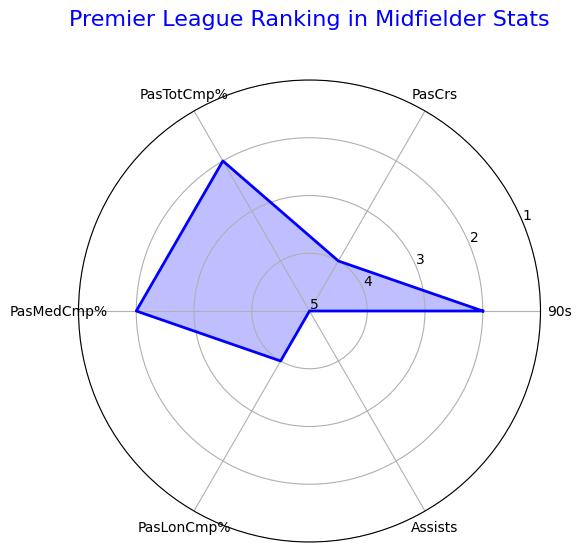

```python
import numpy as np
import matplotlib.pyplot as plt

# Selected stats for the radar chart
graphed_stats = ['90s', 'PasCrs', 'PasTotCmp%', 'PasMedCmp%', 'PasLonCmp%', 'Assists']

# Get the Premier League's rank for these stats
premier_league_ranks = ranked_leagues.loc['Premier League', graphed_stats]

# Normalize ranks: 1 (best) corresponds to 5 bars, 5 (worst) corresponds to 1 bar
# To achieve this, subtract rank from the maximum rank and then normalize
num_leagues = len(ranked_leagues)
normalized_ranks = (num_leagues + 1 - premier_league_ranks)  # Inverse the ranks

# Number of variables we're plotting (should match the number of stats)
num_vars = len(graphed_stats)

# Compute angle for each stat in the radar chart
angles = np.linspace(0, 2 * np.pi, num_vars, endpoint=False).tolist()

# The radar chart requires the plot to be a closed shape
angles += angles[:1]  # Close the circle

# Normalize ranks for radar chart and close the shape by repeating the first value
normalized_ranks = normalized_ranks.tolist()
normalized_ranks += normalized_ranks[:1]  # Close the circle

# Create the radar chart
fig, ax = plt.subplots(figsize=(6, 6), subplot_kw=dict(polar=True))

# Plot data
ax.fill(angles, normalized_ranks, color='blue', alpha=0.25)
ax.plot(angles, normalized_ranks, color='blue', linewidth=2)

# Set the labels for each angle on the radar chart
ax.set_xticks(angles[:-1])  # Match the number of labels with the stats
ax.set_xticklabels(graphed_stats)

# Set the title of the radar chart
ax.set_title('Premier League Ranking in Midfielder Stats', size=16, color='blue', y=1.1)

# Set the range for the radial axis (1 to 5)
ax.set_ylim(1, num_leagues)  # Adjust the range according to number of leagues

# Reverse the radial axis so that rank 1 is on the outer edge and rank 5 is in the center
ax.set_yticks(range(1, num_leagues + 1))
ax.set_yticklabels([str(i) for i in range(num_leagues, 0, -1)])  # Labels should be in reverse order
ax.set_ylim(1, num_leagues)

# Show the plot
plt.show()
```

```python
from google.colab import drive
drive.mount('/content/drive')
```

```python
!ls /content/drive/My\ Drive/Colab\ Notebooks/
```

```
'Copy of Demo-01.ipynb'  'Copy of Lab05.ipynb'		      'Project Milestone 1 - Submission'
'Copy of Demo-02.ipynb'  'Copy of Lab06.ipynb'		       Untitled
'Copy of Demo-05.ipynb'  'Copy of Lab07.ipynb'		       Untitled0.ipynb
'Copy of Lab01.ipynb'	  CopyofProjectMilestone1	      'Untitled (1)'
'Copy of Lab02.ipynb'	  CopyofProjectMilestone.html	      'Untitled (2)'
'Copy of Lab03.ipynb'	 'Copy of Untitled0.ipynb'
'Copy of Lab04.ipynb'	 'Final Copy of Project Milestone 1'
```

```python
%%shell
jupyter nbconvert --to html .ipynb
```

[output not shown]

[output cut: 133 more lines]

[output not shown]

[output not shown]